# NY Times API: Code Base

Author

Lakeranie Boodram

## Step 1: Load Required R Packages

For this project, I will make use of the New York Times Most Popular API in order to get data on the most popular news articles during the last 30 days. I expect to identify the most frequently appearing news subsections as per the retrieved articles.

I will work on R to connect to the API and collect the JSON data in addition to cleaning and structuring the data before coming up with visualizations that will help to analyze the news categories.

**Research Question:** Which New York Times news sections appear most frequently among the most-viewed articles over a 30-day period?

```r
# Install packages if they are not already installed
packages <- c("httr", "jsonlite", "dplyr", "ggplot2")

new_packages <- packages[
  !packages %in% installed.packages()[, "Package"]
]

if (length(new_packages) > 0) {
  install.packages(new_packages)
}

# Load packages
library(httr)
library(jsonlite)
library(dplyr)
library(ggplot2)
```

## Step 2: Connect to the New York Times API

I will use the New York Times Most Popular API to retrieve the most-viewed articles over a 30-day period. My API key is securely stored in an environment variable so that it does not appear in the published document.

```r
# Retrieve API key from environment
api_key <- Sys.getenv("NYT_API_KEY")

# Confirm the API key exists without displaying it
if (!nzchar(api_key)) {
  stop("NYT_API_KEY is missing.")
}

# Define the Most Popular API endpoint
api_url <- "https://api.nytimes.com/svc/mostpopular/v2/viewed/30.json"
```

## Step 3: Verify the API Connection

After setting up the API endpoint, I will send an HTTP GET request to the New York Times API. I will check the response status code to confirm that the request was successful before retrieving and analyzing the data.

```r
# Send request to the New York Times API
response <- GET(
  url = api_url,
  query = list("api-key" = api_key)
)

# Check response status
status_code(response)
```

```
[1] 200
```

```r
# Stop execution if the request fails
stop_for_status(response)
```

## Step 4: Retrieve and Import the Data

After successfully connecting to the New York Times API, I will retrieve the JSON response and convert it into a data frame using the `jsonlite` package. This will make it easier to examine the articles and prepare the data for analysis.

```r
# Confirm that the API request was successful
stop_for_status(response)

# Convert JSON response into an R object
nyt_data <- jsonlite::fromJSON(
  httr::content(response, as = "text", encoding = "UTF-8"),
  flatten = TRUE
)

# Extract articles from the API results
articles <- as.data.frame(nyt_data$results)

# Display the total number of articles
nrow(articles)
```

```
[1] 20
```

```r
# Display the first six articles

head(
  articles[, c("title", "section", "published_date")],
  6
)
```

```
                                                                         title
1                                                                 Latest Polls
2       Patrick Stewart, Master of Shakespeare, ‘Star Trek’ and More, Has Died
3 She Was Offered $40 Million for Silence on Elon Musk. She Spoke Out Instead.
4  Obama’s ‘Cheesecake Factory’ Jab Rankles Trump on Mississippi Campaign Stop
5             It Can Keep Cancer in Remission. Why Is No One Talking About It?
6             How Cornell Punished Each of the 7 Men Accused of Sexual Assault
   section published_date
1    Polls     2026-09-10
2     Arts     2026-10-29
3   Movies     2026-10-09
4     U.S.     2026-10-26
5     Well     2026-10-06
6 New York     2026-10-03
```

## Step 5: Clean and Organize the Data

Now that the data has been imported, I will select the columns that are most relevant to my research question. I will focus on the article titles, news sections, publication dates, URLs, and abstracts.

I will also check for missing values and duplicate articles to make sure the dataset is organized before moving on to the analysis.

```r
# Select relevant columns
articles_clean <- articles %>%
  select(
    title,
    section,
    published_date,
    url,
    abstract
  ) %>%
  distinct(url, .keep_all = TRUE) %>%
  filter(
    !is.na(section),
    trimws(section) != ""
  ) %>%
  mutate(
    published_date = as.Date(published_date),
    section = trimws(section)
  )

# Display first six rows
head(articles_clean)
```

```
                                                                         title
1                                                                 Latest Polls
2       Patrick Stewart, Master of Shakespeare, ‘Star Trek’ and More, Has Died
3 She Was Offered $40 Million for Silence on Elon Musk. She Spoke Out Instead.
4  Obama’s ‘Cheesecake Factory’ Jab Rankles Trump on Mississippi Campaign Stop
5             It Can Keep Cancer in Remission. Why Is No One Talking About It?
6             How Cornell Punished Each of the 7 Men Accused of Sexual Assault
   section published_date
1    Polls     2026-09-10
2     Arts     2026-10-29
3   Movies     2026-10-09
4     U.S.     2026-10-26
5     Well     2026-10-06
6 New York     2026-10-03
                                                                                                                           url
1                                                                  https://www.nytimes.com/interactive/polls/latest-polls.html
2                                                 https://www.nytimes.com/2026/10/29/arts/television/patrick-stewart-dead.html
3                                           https://www.nytimes.com/2026/10/09/movies/ashley-st-clair-interview-elon-musk.html
4 https://www.nytimes.com/2026/10/26/us/politics/obamas-cheesecake-factory-jab-rankles-trump-on-mississippi-campaign-stop.html
5                                            https://www.nytimes.com/2026/10/06/well/cancer-prevention-exercise-treatment.html
6                                           https://www.nytimes.com/2026/10/03/nyregion/cornell-men-university-discipline.html
                                                                                                                                                                      abstract
1                      Track all the polls from today, including the latest data on the 2026 midterm elections, governor’s races, President Trump’s approval rating and more.
2                                                      The British actor was 86. He achieved pop-culture stardom as Capt. Jean-Luc Picard on “Star Trek: The Next Generation.”
3                    In the documentary “Musk,” Ashley St. Clair, a former right-wing influencer and mother of one of Musk’s children, speaks about her relationship with him.
4                         Former President Barack Obama had cast his successor as out of touch while jabbing at his extravagant sense of style. Mr. Trump responded at length.
5                                                                Despite mounting evidence that exercise programs can improve cancer outcomes, access to them remains limited.
6 Summaries obtained by The New York Times offer a detailed look at the discipline meted out to the men accused of sexually assaulting a fellow student at Cornell University.
```

```r
# Check for missing values
colSums(is.na(articles_clean))
```

```
         title        section published_date            url       abstract
             0              0              0              0              0
```

```r
# Display number of cleaned articles
nrow(articles_clean)
```

```
[1] 20
```

## Step 6: Analyze the Most-Viewed News Sections

After cleaning the dataset, I will group the articles by their news sections to determine which categories appear most frequently. I will calculate the number of articles in each section and the percentage they represent in the dataset.

This will help me compare different news categories and identify which sections have the highest representation among the most-viewed articles.

```r
# Count articles by news section
section_counts <- articles_clean %>%
  count(section, name = "article_count", sort = TRUE) %>%
  mutate(
    percentage = round(
      article_count / sum(article_count) * 100, 2
    )
  )

# Display the results
print(section_counts)
```

```
     section article_count percentage
1       U.S.            11         55
2    Opinion             3         15
3       Arts             1          5
4     Movies             1          5
5   New York             1          5
6      Polls             1          5
7 Technology             1          5
8       Well             1          5
```

## Step 7: Visualize the Results

### Initial Findings

Based on the data retrieved from the New York Times Most Popular API, the U.S. section had the highest number of articles, with 11 out of 20 articles representing 55% of the dataset.

The Opinion section followed with 3 articles, accounting for 15%. The remaining sections, including Arts, Movies, New York, Polls, Technology, and Well, each contained one article, representing 5% individually.

These results suggest that U.S. news was the most represented category among the most-viewed articles returned by the API during the selected 30-day period. However, this does not necessarily mean the U.S. section received 55% of all article views.

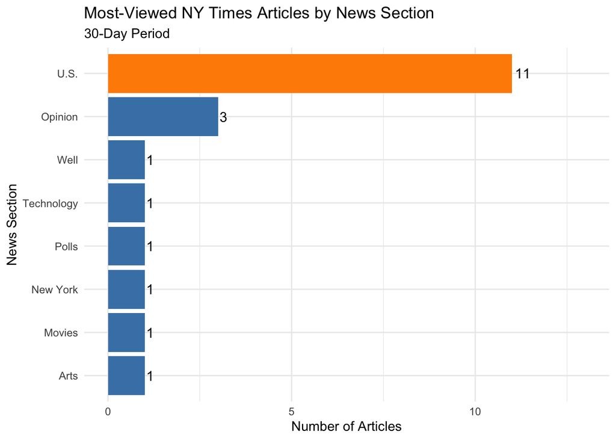

```r
# Create a horizontal bar chart
ggplot(
  section_counts,
  aes(
    x = reorder(section, article_count),
    y = article_count,
    fill = section == "U.S."
  )
) +
  geom_col() +
  geom_text(
    aes(label = article_count),
    hjust = -0.2,
    size = 4
  ) +
  coord_flip() +
  scale_fill_manual(
    values = c("FALSE" = "steelblue",
               "TRUE" = "darkorange"),
    guide = "none"
  ) +
  scale_y_continuous(
    limits = c(0, max(section_counts$article_count) + 2)
  ) +
  labs(
    title = "Most-Viewed NY Times Articles by News Section",
    subtitle = "30-Day Period",
    x = "News Section",
    y = "Number of Articles"
  ) +
  theme_minimal()
```

## Step 8: Results and Findings

After analyzing the data from the New York Times Most Popular API, I found that the U.S. section had the highest representation among the most-viewed articles during the selected 30-day period.

Out of the 20 articles returned by the API, 11 belonged to the U.S. section, representing 55% of the dataset. Opinion was the second most represented section, with 3 articles accounting for 15%.

The remaining categories, including Arts, Movies, New York, Polls, Technology, and Well, each had one article, representing 5% individually.

The bar chart makes it easier to see the difference between the news categories. The U.S. section had significantly more articles than any other category in the dataset.

These findings answer my research question by showing that U.S. news appeared most frequently among the articles returned by the Most Popular API. However, because the dataset contains only 20 articles and does not provide actual view counts, I cannot conclude that U.S. news received the majority of all reader views

## Step 9: Conclusion

The purpose of this project was to utilize the New York Times Most Popular API for accessing and understanding the world of news through real-world news data.

I implemented R in order to connect to the API, read the JSON response, clean and arrange the dataset, so that articles were classified by their news sections. I also prepared a bar chart to represent my findings visually.

The results indicated that the U.S. has become the most common section by counting for 55% of the articles, with opinion coming second at 15%.

The limitation of the analysis is that the API only provides a limited selection of articles, rather than providing their actual readership statistics. Thus, the results only reflect the distribution of news sections across the collected articles.

In conclusion, this project helped to learn how to apply APIs in data science for data collection, processing, extraction and visualization.

## References

The New York Times. (n.d.). *Most Popular API*. The New York Times Developer Network. https://developer.nytimes.com/docs/most-popular-product/1/overview

Wickham, H. (n.d.). *httr quickstart vignette*. CRAN. https://cran.r-project.org/web/packages/httr/vignettes/quickstart.html